# Vigorous Physical Activity

# 1 Description of DataSchema variable

The description of harmonised variable is the following:

- Short name: `vig_pa`
- Variable label: `Engage in vigorous exercise during the last 2 weeks`
- Variable description: `Engage in vigorous exercise during the last 2 weeks`
- Domain: `Lifestyle and health behaviours`
- Value type: `categorical`
- Category coding:

| **Code** | **Category Label** |
| --- | --- |
| 0 | No |
| 1 | Yes |

- Category missings:

| **Code** | **Category Label** |
| --- | --- |
| 991 | CAPI/interviewer error |
| 992 | Impute |
| 993 | Disable to measure |
| 994 | Not attempt/not done |
| 995 | Does not answer |
| 996 | Not applicable |
| 997 | Refuse |
| 998 | Do not know |
| 999 | Missing |

# 2 Data process

## 2.1 England

### 2.1.1 Wave 1

#### 2.1.1.1 Study-specific variable description

| **Name** | `heacta` |
| --- | --- |
| **Label** | `Do you take part in sports or activities that are vigorous?` |
| **Table name** | `wave_1_core_data_v3` |
| **Categories** | `1 = More than once a week` `2 = once a week,` `3 = one to three times a month,` `4 = Hardly ever or never` |
| **Missings** | `-1 = Not applicable` `-8 = Don't Know` `-9 = Refusal` |
| **Description** |  |

heacta

| Sample size | Missing values |
| --- | --- |
| 12099 | 194 |

Category

|  | 1 | 2 | 3 | 4 |
| --- | --- | --- | --- | --- |
| Frequency | 2145.00 | 1157.00 | 1122.00 | 7481.00 |
| Percentage | 17.73 | 9.56 | 9.27 | 61.83 |

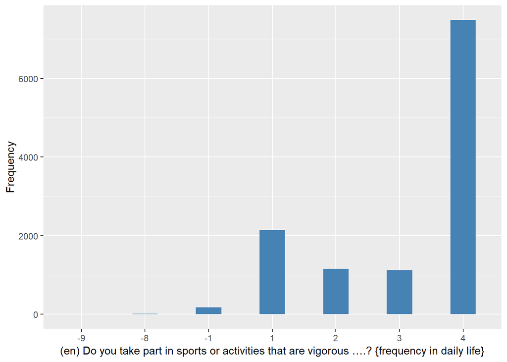

#### 2.1.1.2 Harmonisation algorithm

To compute `vig_pa` from the study-specific variable it has to be recoded as follows:

- `1,2,3 into 1`
- `4 into 0`
- `-9 into 997`
- `-8 into 998`
- `-1 into 996`

**R script:**

```r
ELSA_ds_w1 <- tibble(id = ELSA_w1$id)
ELSA_ds_w1$vig_pa <- car::recode(ELSA_w1$heacta, "2 = 1;3 = 1;4 = 0;-9 = 997;-8 = 998;-1 = 996 ")
```

#### 2.1.1.3 Statistical description of the new harmonised variable

Engage in vigorous exercise during the last 2 weeks

| Sample size | Missing values |
| --- | --- |
| 12099 | 194 |

Category

|  | 0 | 1 |
| --- | --- | --- |
| Frequency | 7481.00 | 4424.00 |
| Percentage | 61.83 | 36.57 |

Type of missing

|  | 991 | 992 | 993 | 994 | 995 | 996 | 997 | 998 | 999 | NA |
| --- | --- | --- | --- | --- | --- | --- | --- | --- | --- | --- |
| Frequency | 0 | 0 | 0 | 0 | 0 | 175.00 | 5.00 | 14.00 | 0 | 0 |
| Percentage | 0 | 0 | 0 | 0 | 0 | 1.45 | 0.04 | 0.12 | 0 | 0 |

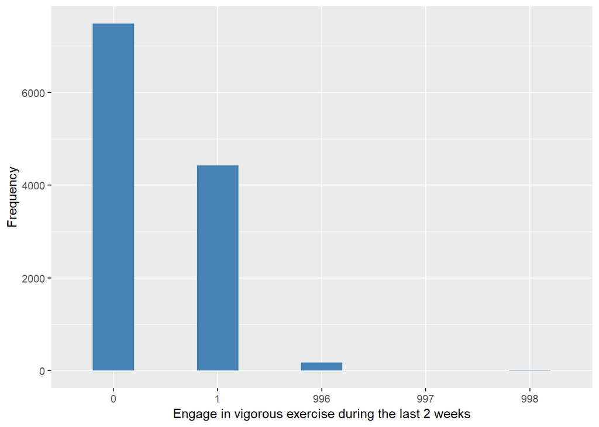

#### 2.1.1.4 Validation

|  | 4->0 | 1,2,3->1 | -1->996 | -9->997 | -8->998 |
| --- | --- | --- | --- | --- | --- |
| BeforeH | 7481 | 4424 | 175 | 5 | 14 |
| AfterH | 7481 | 4424 | 175 | 5 | 14 |

### 2.1.2 Wave 2

#### 2.1.2.1 Study-specific variable description

| **Name** | `HeActa` |
| --- | --- |
| **Label** | `Frequency does vigorous sports or activities` |
| **Table name** | `wave_2_core_data_v4` |
| **Categories** | `1 = More than once a week` `2 = once a week,` `3 = one to three times a month,` `4 = Hardly ever or never` |
| **Missings** | `-1 = Not applicable` `-9 = Refusal` |
| **Description** |  |

HeActa

| Sample size | Missing values |
| --- | --- |
| 9432 | 133 |

Category

|  | 1 | 2 | 3 | 4 |
| --- | --- | --- | --- | --- |
| Frequency | 1661.00 | 905.00 | 987.00 | 5746.00 |
| Percentage | 17.61 | 9.59 | 10.46 | 60.92 |

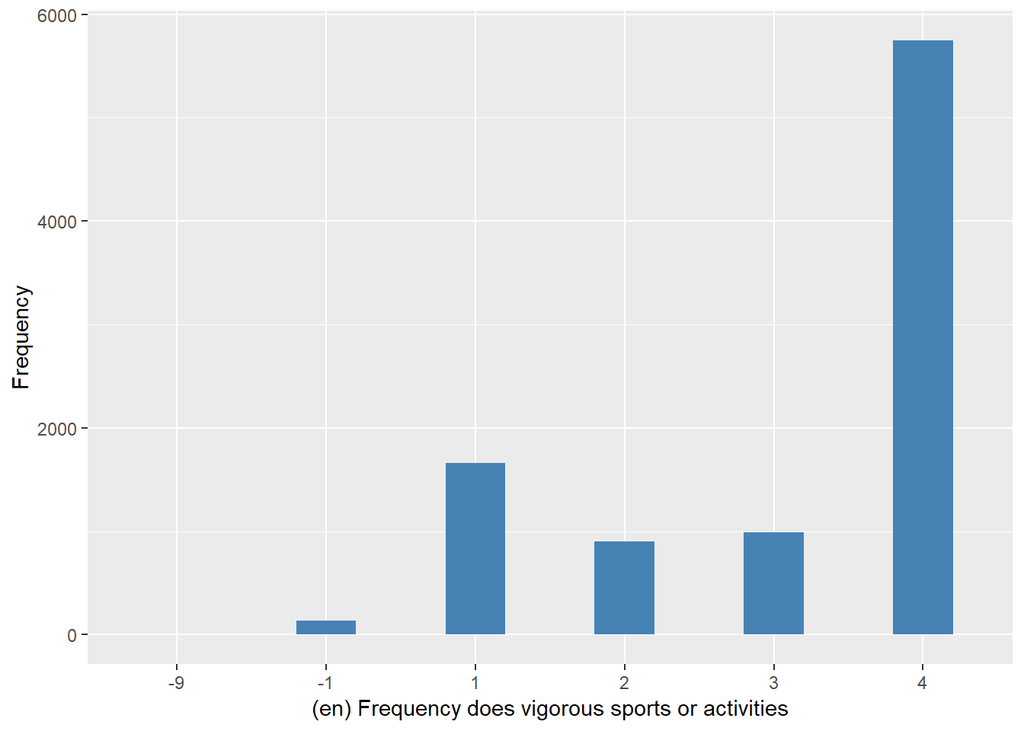

#### 2.1.2.2 Harmonisation algorithm

To compute `vig_pa` from the study-specific variable it has to be recoded as follows:

- `1,2,3 into 1`
- `4 into 0`
- `-9 into 997`
- `-1 into 996`

**R script:**

```r
ELSA_ds_w2 <- tibble(id = ELSA_w2$id)
ELSA_ds_w2$vig_pa <- car::recode(ELSA_w2$HeActa, "2 = 1;3 = 1;4 = 0;-9 = 997;-1 = 996 ")
```

#### 2.1.2.3 Statistical description of the new harmonised variable

Engage in vigorous exercise during the last 2 weeks

| Sample size | Missing values |
| --- | --- |
| 9432 | 133 |

Category

|  | 0 | 1 |
| --- | --- | --- |
| Frequency | 5746.00 | 3553.00 |
| Percentage | 60.92 | 37.67 |

Type of missing

|  | 991 | 992 | 993 | 994 | 995 | 996 | 997 | 998 | 999 | NA |
| --- | --- | --- | --- | --- | --- | --- | --- | --- | --- | --- |
| Frequency | 0 | 0 | 0 | 0 | 0 | 132.0 | 1.00 | 0 | 0 | 0 |
| Percentage | 0 | 0 | 0 | 0 | 0 | 1.4 | 0.01 | 0 | 0 | 0 |

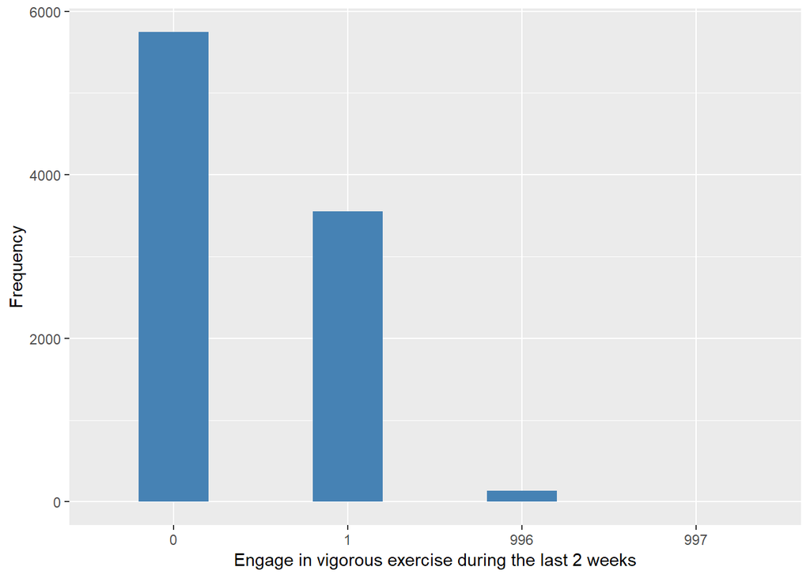

#### 2.1.2.4 Validation

|  | 4->0 | 1,2,3->1 | -1->996 | -9->997 |
| --- | --- | --- | --- | --- |
| BeforeH | 5746 | 3553 | 132 | 1 |
| AfterH | 5746 | 3553 | 132 | 1 |

### 2.1.3 Wave 3

#### 2.1.3.1 Study-specific variable description

| **Name** | `heacta` |
| --- | --- |
| **Label** | `Frequency does vigorous sports or activities` |
| **Table name** | `wave_3_elsa_data_v4` |
| **Categories** | `1 = More than once a week` `2 = once a week,` `3 = one to three times a month,` `4 = Hardly ever or never` |
| **Missings** | `-8 = Don't Know` `-9 = Refusal` |
| **Description** |  |

heacta

| Sample size | Missing values |
| --- | --- |
| 9771 | 2 |

Category

|  | 1 | 2 | 3 | 4 |
| --- | --- | --- | --- | --- |
| Frequency | 1899.00 | 891.00 | 934.00 | 6045.00 |
| Percentage | 19.44 | 9.12 | 9.56 | 61.87 |

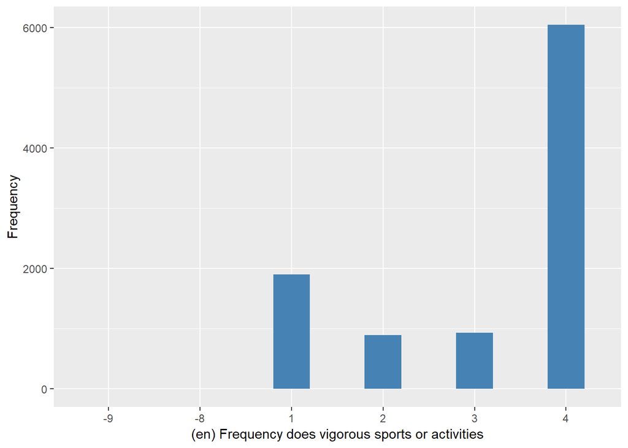

#### 2.1.3.2 Harmonisation algorithm

To compute `vig_pa` from the study-specific variable it has to be recoded as follows:

- `1,2,3 into 1`
- `4 into 0`
- `-9 into 997`
- `-8 into 998`

**R script:**

```r
ELSA_ds_w3 <- tibble(id = ELSA_w3$id)
ELSA_ds_w3$vig_pa <- car::recode(ELSA_w3$heacta, "2 = 1;3 = 1;4 = 0;-9 = 997;-8 = 998 ")
```

#### 2.1.3.3 Statistical description of the new harmonised variable

Engage in vigorous exercise during the last 2 weeks

| Sample size | Missing values |
| --- | --- |
| 9771 | 2 |

Category

|  | 0 | 1 |
| --- | --- | --- |
| Frequency | 6045.00 | 3724.00 |
| Percentage | 61.87 | 38.11 |

Type of missing

|  | 991 | 992 | 993 | 994 | 995 | 996 | 997 | 998 | 999 | NA |
| --- | --- | --- | --- | --- | --- | --- | --- | --- | --- | --- |
| Frequency | 0 | 0 | 0 | 0 | 0 | 0 | 1.00 | 1.00 | 0 | 0 |
| Percentage | 0 | 0 | 0 | 0 | 0 | 0 | 0.01 | 0.01 | 0 | 0 |

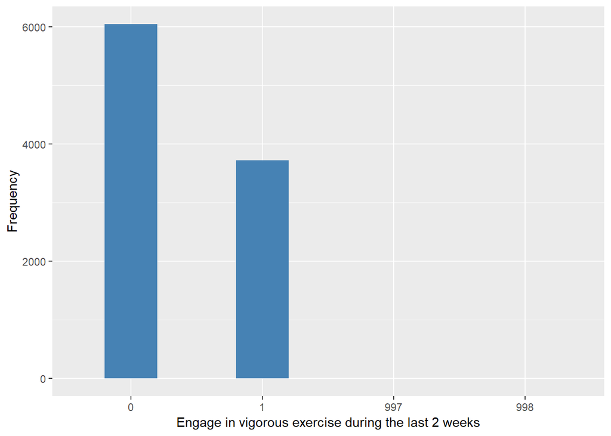

#### 2.1.3.4 Validation

|  | 4->0 | 1,2,3->1 | -9->997 | -8->998 |
| --- | --- | --- | --- | --- |
| BeforeH | 6045 | 3724 | 1 | 1 |
| AfterH | 6045 | 3724 | 1 | 1 |

### 2.1.4 Wave 4

#### 2.1.4.1 Study-specific variable description

| **Name** | `heacta` |
| --- | --- |
| **Label** | `Frequency does vigorous sports or activities` |
| **Table name** | `wave_4_elsa_data_v3` |
| **Categories** | `1 = More than once a week` `2 = once a week,` `3 = one to three times a month,` `4 = Hardly ever or never` |
| **Missings** | `-8 = Don't Know` `-9 = Refusal` |
| **Description** |  |

heacta

| Sample size | Missing values |
| --- | --- |
| 11050 | 11 |

Category

|  | 1 | 2 | 3 | 4 |
| --- | --- | --- | --- | --- |
| Frequency | 2164.00 | 1035.00 | 1059.00 | 6781.00 |
| Percentage | 19.58 | 9.37 | 9.58 | 61.37 |

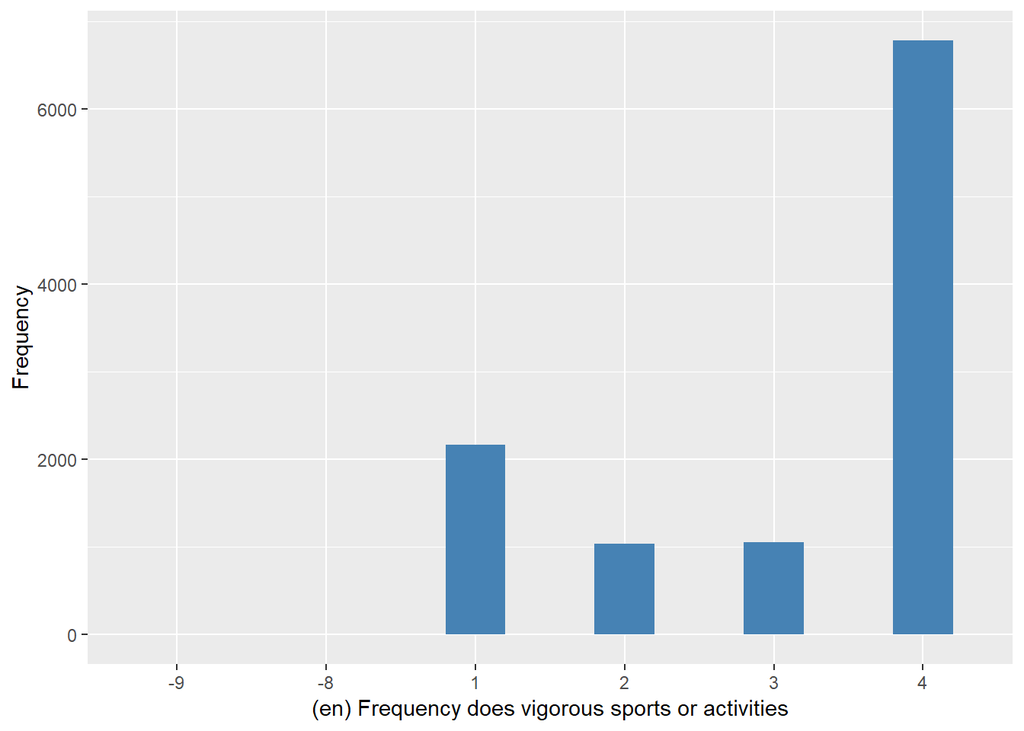

#### 2.1.4.2 Harmonisation algorithm

To compute `vig_pa` from the study-specific variable it has to be recoded as follows:

- `1,2,3 into 1`
- `4 into 0`
- `-9 into 997`
- `-8 into 998`

**R script:**

```r
ELSA_ds_w4 <- tibble(id = ELSA_w4$id)
ELSA_ds_w4$vig_pa <- car::recode(ELSA_w4$heacta, "2 = 1;3 = 1;4 = 0;-9 = 997;-8 = 998 ")
```

#### 2.1.4.3 Statistical description of the new harmonised variable

Engage in vigorous exercise during the last 2 weeks

| Sample size | Missing values |
| --- | --- |
| 11050 | 11 |

Category

|  | 0 | 1 |
| --- | --- | --- |
| Frequency | 6781.00 | 4258.00 |
| Percentage | 61.37 | 38.53 |

Type of missing

|  | 991 | 992 | 993 | 994 | 995 | 996 | 997 | 998 | 999 | NA |
| --- | --- | --- | --- | --- | --- | --- | --- | --- | --- | --- |
| Frequency | 0 | 0 | 0 | 0 | 0 | 0 | 7.00 | 4.00 | 0 | 0 |
| Percentage | 0 | 0 | 0 | 0 | 0 | 0 | 0.06 | 0.04 | 0 | 0 |

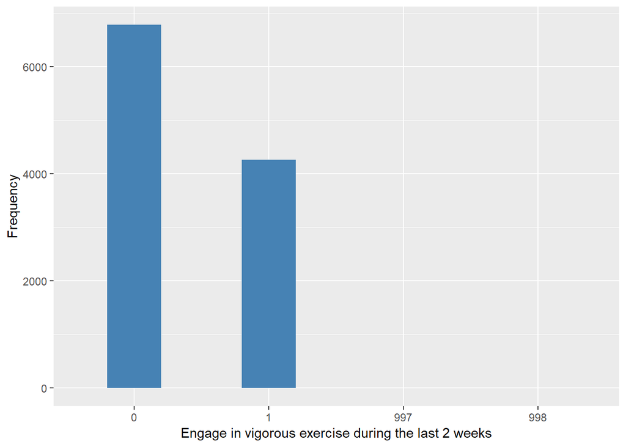

#### 2.1.4.4 Validation

|  | 4->0 | 1,2,3->1 | -9->997 | -8->998 |
| --- | --- | --- | --- | --- |
| BeforeH | 6781 | 4258 | 7 | 4 |
| AfterH | 6781 | 4258 | 7 | 4 |

### 2.1.5 Wave 5

#### 2.1.5.1 Study-specific variable description

| **Name** | `heacta` |
| --- | --- |
| **Label** | `Frequency does vigorous sports or activities` |
| **Table name** | `wave_5_elsa_data_v4` |
| **Categories** | `1 = More than once a week` `2 = once a week,` `3 = one to three times a month,` `4 = Hardly ever or never` |
| **Missings** | `-8 = Don't Know` `-9 = Refusal` |
| **Description** |  |

heacta

| Sample size | Missing values |
| --- | --- |
| 10274 | 10 |

Category

|  | 1 | 2 | 3 | 4 |
| --- | --- | --- | --- | --- |
| Frequency | 1951.00 | 975.00 | 1049.00 | 6289.00 |
| Percentage | 18.99 | 9.49 | 10.21 | 61.21 |

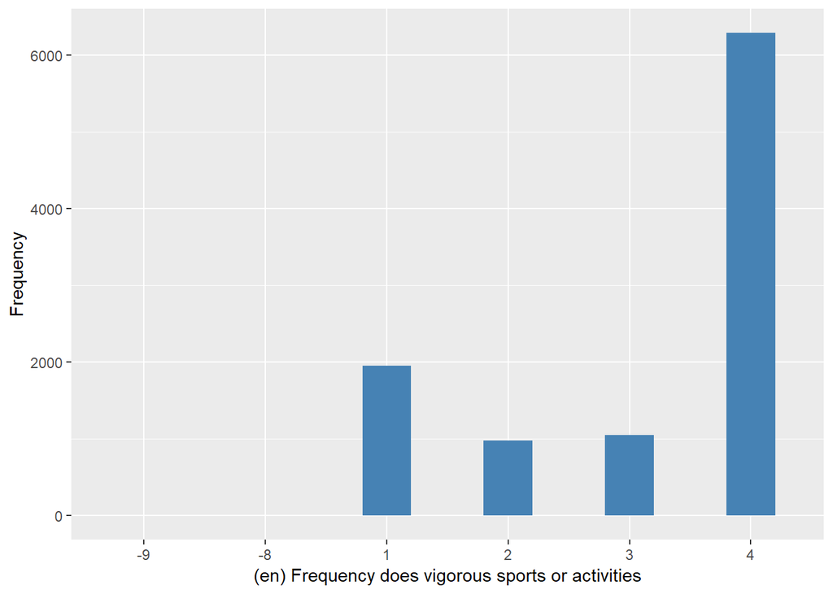

#### 2.1.5.2 Harmonisation algorithm

To compute `vig_pa` from the study-specific variable it has to be recoded as follows:

- `1,2,3 into 1`
- `4 into 0`
- `-9 into 997`
- `-8 into 998`

**R script:**

```r
ELSA_ds_w5 <- tibble(id = ELSA_w5$id)
ELSA_ds_w5$vig_pa <- car::recode(ELSA_w5$heacta, "2 = 1;3 = 1;4 = 0;-9 = 997;-8 = 998 ")
```

#### 2.1.5.3 Statistical description of the new harmonised variable

Engage in vigorous exercise during the last 2 weeks

| Sample size | Missing values |
| --- | --- |
| 10274 | 10 |

Category

|  | 0 | 1 |
| --- | --- | --- |
| Frequency | 6289.00 | 3975.00 |
| Percentage | 61.21 | 38.69 |

Type of missing

|  | 991 | 992 | 993 | 994 | 995 | 996 | 997 | 998 | 999 | NA |
| --- | --- | --- | --- | --- | --- | --- | --- | --- | --- | --- |
| Frequency | 0 | 0 | 0 | 0 | 0 | 0 | 5.00 | 5.00 | 0 | 0 |
| Percentage | 0 | 0 | 0 | 0 | 0 | 0 | 0.05 | 0.05 | 0 | 0 |

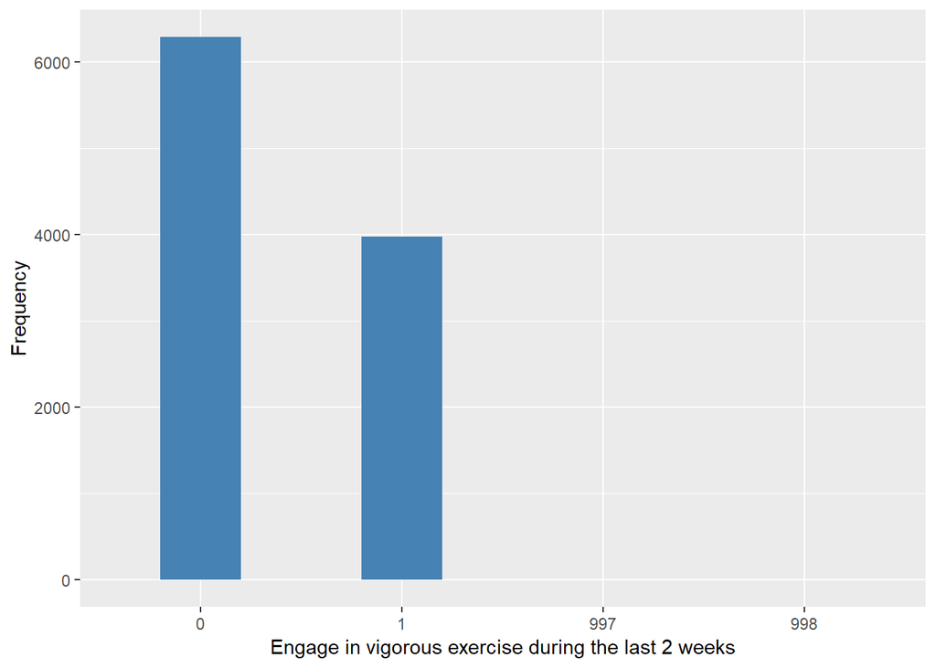

#### 2.1.5.4 Validation

|  | 4->0 | 1,2,3->1 | -9->997 | -8->998 |
| --- | --- | --- | --- | --- |
| BeforeH | 6289 | 3975 | 5 | 5 |
| AfterH | 6289 | 3975 | 5 | 5 |

### 2.1.6 Wave 6

#### 2.1.6.1 Study-specific variable description

| **Name** | `HeActa` |
| --- | --- |
| **Label** | `Frequency does vigorous sports or activities` |
| **Table name** | `wave_6_elsa_data_v2` |
| **Categories** | `1 = More than once a week` `2 = once a week,` `3 = one to three times a month,` `4 = Hardly ever or never` |
| **Missings** | `-8 = Don't Know` `-9 = Refusal` |
| **Description** |  |

HeActa

| Sample size | Missing values |
| --- | --- |
| 10601 | 5 |

Category

|  | 1 | 2 | 3 | 4 |
| --- | --- | --- | --- | --- |
| Frequency | 2177.00 | 979.00 | 982.00 | 6458.00 |
| Percentage | 20.54 | 9.23 | 9.26 | 60.92 |

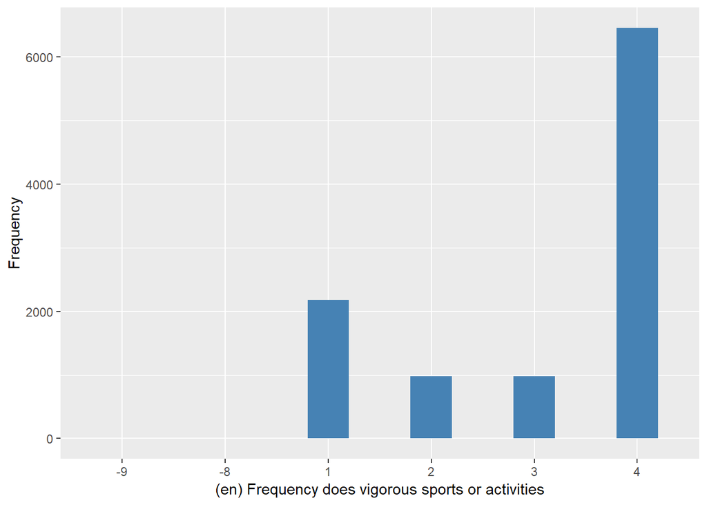

#### 2.1.6.2 Harmonisation algorithm

To compute `vig_pa` from the study-specific variable it has to be recoded as follows:

- `1,2,3 into 1`
- `4 into 0`
- `-9 into 997`
- `-8 into 998`

**R script:**

```r
ELSA_ds_w6 <- tibble(id = ELSA_w6$id)
ELSA_ds_w6$vig_pa <- car::recode(ELSA_w6$HeActa, "2 = 1;3 = 1;4 = 0;-9 = 997;-8 = 998 ")
```

#### 2.1.6.3 Statistical description of the new harmonised variable

Engage in vigorous exercise during the last 2 weeks

| Sample size | Missing values |
| --- | --- |
| 10601 | 5 |

Category

|  | 0 | 1 |
| --- | --- | --- |
| Frequency | 6458.00 | 4138.00 |
| Percentage | 60.92 | 39.03 |

Type of missing

|  | 991 | 992 | 993 | 994 | 995 | 996 | 997 | 998 | 999 | NA |
| --- | --- | --- | --- | --- | --- | --- | --- | --- | --- | --- |
| Frequency | 0 | 0 | 0 | 0 | 0 | 0 | 4.00 | 1.00 | 0 | 0 |
| Percentage | 0 | 0 | 0 | 0 | 0 | 0 | 0.04 | 0.01 | 0 | 0 |

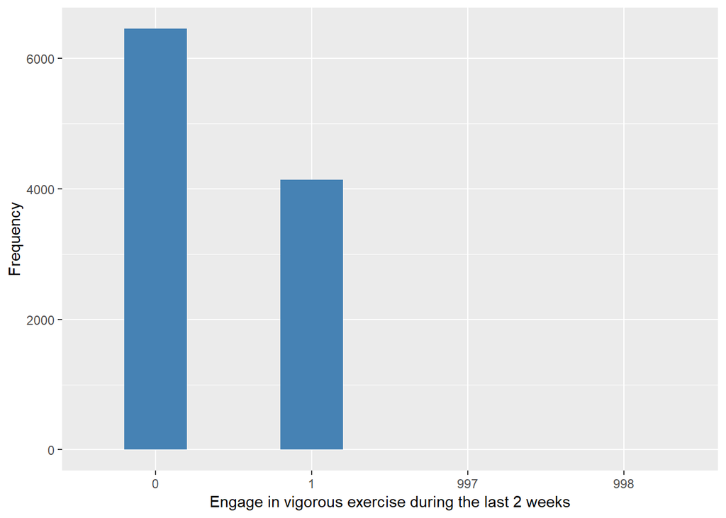

#### 2.1.6.4 Validation

|  | 4->0 | 1,2,3->1 | -9->997 | -8->998 |
| --- | --- | --- | --- | --- |
| BeforeH | 6458 | 4138 | 4 | 1 |
| AfterH | 6458 | 4138 | 4 | 1 |

### 2.1.7 Wave 7

#### 2.1.7.1 Study-specific variable description

| **Name** | `HeActa` |
| --- | --- |
| **Label** | `Frequency does vigorous sports or activities` |
| **Table name** | `wave_7_elsa_data` |
| **Categories** | `1 = ...more than once a week,` `2 = once a week,` `3 = one to three times a month,` `4 = hardly ever, or never?` |
| **Missings** | `-8 = Don't Know` `-9 = Refusal` |
| **Description** |  |

HeActa

| Sample size | Missing values |
| --- | --- |
| 9666 | 4 |

Category

|  | 1 | 2 | 3 | 4 |
| --- | --- | --- | --- | --- |
| Frequency | 1958.00 | 890.00 | 852.00 | 5962.00 |
| Percentage | 20.26 | 9.21 | 8.81 | 61.68 |

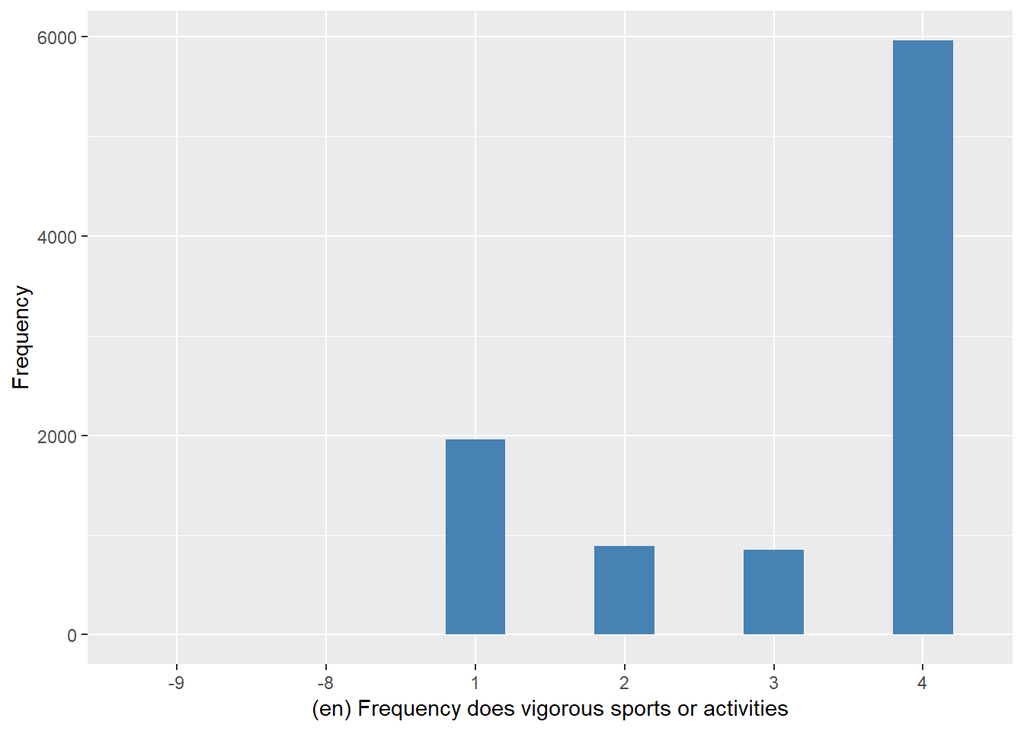

#### 2.1.7.2 Harmonisation algorithm

To compute `vig_pa` from the study-specific variable it has to be recoded as follows:

- `1,2,3 into 1`
- `4 into 0`
- `-9 into 997`
- `-8 into 998`

**R script:**

```r
ELSA_ds_w7 <- tibble(id = ELSA_w7$id)
ELSA_ds_w7$vig_pa <- car::recode(ELSA_w7$HeActa, "2 = 1;3 = 1;4 = 0;-9 = 997;-8 = 998 ")
```

#### 2.1.7.3 Statistical description of the new harmonised variable

Engage in vigorous exercise during the last 2 weeks

| Sample size | Missing values |
| --- | --- |
| 9666 | 4 |

Category

|  | 0 | 1 |
| --- | --- | --- |
| Frequency | 5962.00 | 3700.00 |
| Percentage | 61.68 | 38.28 |

Type of missing

|  | 991 | 992 | 993 | 994 | 995 | 996 | 997 | 998 | 999 | NA |
| --- | --- | --- | --- | --- | --- | --- | --- | --- | --- | --- |
| Frequency | 0 | 0 | 0 | 0 | 0 | 0 | 1.00 | 3.00 | 0 | 0 |
| Percentage | 0 | 0 | 0 | 0 | 0 | 0 | 0.01 | 0.03 | 0 | 0 |

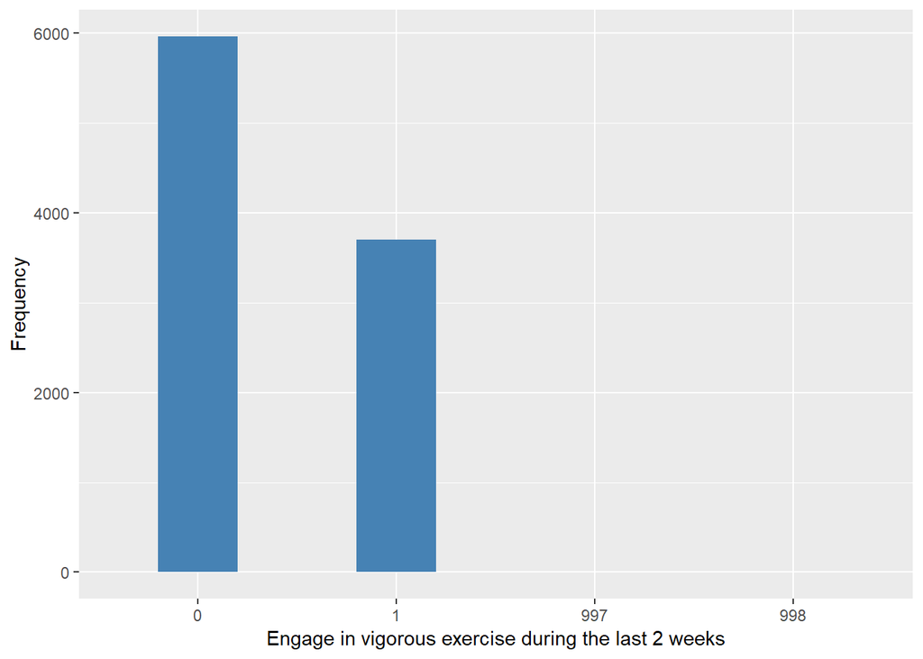

#### 2.1.7.4 Validation

|  | 4->0 | 1,2,3->1 | -9->997 | -8->998 |
| --- | --- | --- | --- | --- |
| BeforeH | 5962 | 3700 | 1 | 3 |
| AfterH | 5962 | 3700 | 1 | 3 |

## 2.2 Summary of descriptive statistics of the harmonised variable accross populations and waves

Two tables are generated:

1. Percentages of categories in each harmonised variable.
2. Frequencies and percentages of individuals with different trajectories. To avoid too large table, only trajectories with percentages larger than 0.3 are shown.

Engage in vigorous exercise during the last 2 weeks

| val | label | W1 | W2 | W3 | W4 | W5 | W6 | W7 |
| --- | --- | --- | --- | --- | --- | --- | --- | --- |
| 0 | No | 61.83 | 60.92 | 61.87 | 61.37 | 61.21 | 60.92 | 61.68 |
| 1 | Yes | 36.57 | 37.67 | 38.11 | 38.53 | 38.69 | 39.03 | 38.28 |
| 991 | CAPI interviewer error | 0 | 0 | 0 | 0 | 0 | 0 | 0 |
| 992 | Impute | 0 | 0 | 0 | 0 | 0 | 0 | 0 |
| 993 | Disable to measure | 0 | 0 | 0 | 0 | 0 | 0 | 0 |
| 994 | Not attempt not done | 0 | 0 | 0 | 0 | 0 | 0 | 0 |
| 995 | Does not answer | 0 | 0 | 0 | 0 | 0 | 0 | 0 |
| 996 | Not applicable | 1.45 | 1.4 | 0 | 0 | 0 | 0 | 0 |
| 997 | Refuse | 0.04 | 0.01 | 0.01 | 0.06 | 0.05 | 0.04 | 0.01 |
| 998 | Do not know | 0.12 | 0 | 0.01 | 0.04 | 0.05 | 0.01 | 0.03 |
| 999 | Missing | 0 | 0 | 0 | 0 | 0 | 0 | 0 |
| NA | NA | 0 | 0 | 0 | 0 | 0 | 0 | 0 |
| n | sample size | 12099 | 9432 | 9771 | 11050 | 10274 | 10601 | 9666 |

|  | val | frq | raw.prc |
| --- | --- | --- | --- |
| 1 | 0000000 | 1057 | 5.72 |
| 3 | 000000NA | 271 | 1.47 |
| 8 | 00000NANA | 250 | 1.35 |
| 9 | 0000100 | 68 | 0.37 |
| 23 | 0000NANANA | 306 | 1.66 |
| 24 | 0001000 | 62 | 0.34 |
| 67 | 000NANANANA | 524 | 2.83 |
| 68 | 0010000 | 76 | 0.41 |
| 161 | 00NANANANANA | 726 | 3.93 |
| 162 | 0100000 | 125 | 0.68 |
| 213 | 010NANANANA | 57 | 0.31 |
| 243 | 0111111 | 68 | 0.37 |
| 292 | 01NANANANANA | 123 | 0.67 |
| 323 | 0NA0NANANANA | 80 | 0.43 |
| 391 | 0NANANANANANA | 1462 | 7.91 |
| 392 | 1000000 | 188 | 1.02 |
| 439 | 100NANANANA | 81 | 0.44 |
| 512 | 10NANANANANA | 169 | 0.91 |
| 513 | 1100000 | 87 | 0.47 |
| 567 | 1110000 | 58 | 0.31 |
| 591 | 1111011 | 63 | 0.34 |
| 596 | 1111100 | 75 | 0.41 |
| 597 | 1111101 | 57 | 0.31 |
| 599 | 1111110 | 111 | 0.60 |
| 600 | 1111111 | 499 | 2.70 |
| 635 | 111NANANANA | 101 | 0.55 |
| 673 | 11NANANANANA | 217 | 1.17 |
| 773 | 1NANANANANANA | 564 | 3.05 |
| 837 | NANA00000 | 193 | 1.04 |
| 903 | NANA0NANANANA | 178 | 0.96 |
| 939 | NANA11111 | 192 | 1.04 |
| 968 | NANA1NANANANA | 140 | 0.76 |
| 969 | NANANA0000 | 558 | 3.02 |
| 970 | NANANA0001 | 67 | 0.36 |
| 971 | NANANA000NA | 124 | 0.67 |
| 972 | NANANA0010 | 56 | 0.30 |
| 977 | NANANA00NANA | 95 | 0.51 |
| 978 | NANANA0100 | 94 | 0.51 |
| 982 | NANANA0111 | 70 | 0.38 |
| 995 | NANANA0NANANA | 232 | 1.25 |
| 996 | NANANA1000 | 89 | 0.48 |
| 1005 | NANANA1100 | 66 | 0.36 |
| 1008 | NANANA1110 | 84 | 0.45 |
| 1009 | NANANA1111 | 340 | 1.84 |
| 1022 | NANANA1NANANA | 133 | 0.72 |
| 1040 | NANANANANA00 | 375 | 2.03 |
| 1041 | NANANANANA01 | 109 | 0.59 |
| 1042 | NANANANANA0NA | 143 | 0.77 |
| 1043 | NANANANANA10 | 120 | 0.65 |
| 1044 | NANANANANA11 | 347 | 1.88 |
| 1045 | NANANANANA1NA | 124 | 0.67 |
| 1046 | NANANANANANA0 | 255 | 1.38 |
| 1047 | NANANANANANA1 | 255 | 1.38 |
| 1048 | NANANANANANANA | 109 | 0.59 |

# 3 Quality estimation